# 『完全独習 統計学入門』

@anemptyarchive

2023-01-20 18:59:07

【編集履歴】

- 2023.01.19：初稿完成

# 第5講 標準偏差(S.D.)は、株のリスクの指標(ボラティリティ)として活用できる

前講では、標準偏差の役割を確認しました。この講では、標準偏差をボラティリティとして株の収益率を比較します。

利用するパッケージを読み込みます。

```r
# 利用パッケージ
library(tidyverse)
library(magick)
```

この記事では、基本的に`パッケージ名::関数名()`の記法を使うので、パッケージを読み込む必要はありません。ただし、作図コードがごちゃごちゃしないようにパッケージ名を省略しているため`ggplot2`を読み込む必要があります。  
また、ネイティブパイプ演算子`|>`を使っています。`magrittr`パッケージのパイプ演算子`%>%`に置き換えても処理できますが、その場合は`magrittr`も読み込む必要があります。

## 5-2 平均収益率だけでは、優良な投資かどうかは判断できない

まずは、データを読み込んで、グラフで確認します。

図表5-3のデータセットをデータフレームとして作成します。

```r
# データを作成:(図5-3)
revenue_df_wide <- tibble::tibble(
  month = 1:12,
  year_1980 = c(9.2, 2.3, -6.5, 9, 5.3, -4.3, -3.7, 7, 7.6, 1.4, -3.4, 0.7),
  year_1981 = c(2.8, -1.4, 17.6, 17.8, 5.5, -1.9, 1.9, 9, -10.3, -10.3, -7.7, 6.5),
  year_1982 = c(-0.6, -11.8, 3.5, 1.9, -5.5, -9.1, -5.7, 2.3, -4.9, -0.8, 8, 6.7),
  year_1983 = c(-2.8, 9.3, 11.4, 3, -7.5, 2.5, -0.6, 1.8, 5.1, -2.3, -6, 10.6),
  year_1984 = c(0, -5.7, 10.6, -0.6, -11.2, -3.8, -5.2, 6.2, -4.2, 2.1, 0.6, 4.7)
)
revenue_df_wide
```

```
## # A tibble: 12 × 6
##    month year_1980 year_1981 year_1982 year_1983 year_1984
##    <int>     <dbl>     <dbl>     <dbl>     <dbl>     <dbl>
##  1     1       9.2       2.8      -0.6      -2.8       0
##  2     2       2.3      -1.4     -11.8       9.3      -5.7
##  3     3      -6.5      17.6       3.5      11.4      10.6
##  4     4       9        17.8       1.9       3        -0.6
##  5     5       5.3       5.5      -5.5      -7.5     -11.2
##  6     6      -4.3      -1.9      -9.1       2.5      -3.8
##  7     7      -3.7       1.9      -5.7      -0.6      -5.2
##  8     8       7         9         2.3       1.8       6.2
##  9     9       7.6     -10.3      -4.9       5.1      -4.2
## 10    10       1.4     -10.3      -0.8      -2.3       2.1
## 11    11      -3.4      -7.7       8        -6         0.6
## 12    12       0.7       6.5       6.7      10.6       4.7
```

5年分の株の月次収益率です。

作図用に、各年の収益率のデータ(列)を1列にまとめます。

```r
# 縦型のデータフレームに変換
revenue_df <- revenue_df_wide |>
  tidyr::pivot_longer(
    cols = !month,
    names_to = "year",
    names_prefix = "year_",
    names_ptypes = list(year = factor()),
    values_to = "revenue_rate"
  )
revenue_df
```

```
## # A tibble: 60 × 3
##    month year  revenue_rate
##    <int> <fct>        <dbl>
##  1     1 1980           9.2
##  2     1 1981           2.8
##  3     1 1982          -0.6
##  4     1 1983          -2.8
##  5     1 1984           0
##  6     2 1980           2.3
##  7     2 1981          -1.4
##  8     2 1982         -11.8
##  9     2 1983           9.3
## 10     2 1984          -5.7
## # … with 50 more rows
```

`pivot_longer()`で横型のデータフレームを縦型に変換します。`cols`引数に変換する列(変換しない列を指定する場合は頭に`!`を付けます)、`names_to`引数に「現在の列名」を格納する新たな列の名前、`values_to`引数に「現在の各列の値」を格納する新たな列の名前を指定します。また、`names_prefix`引数に現列名の頭から取り除く文字列、`names_ptypes`(または`names_transform`)引数で格納後の型を指定できます。

年ごとに収益率の推移のグラフを作成します。

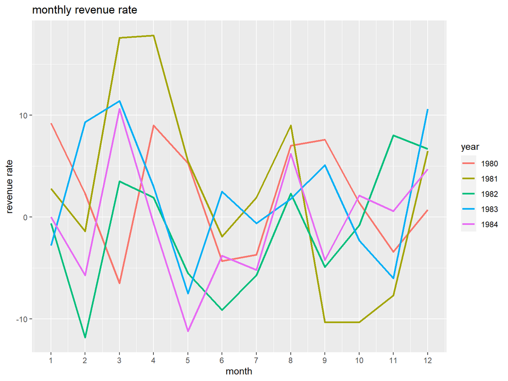

```r
# 月次収益率を作図
ggplot() +
  geom_line(data = revenue_df,
            mapping = aes(x = month, y = revenue_rate, color = year),
            size = 1) + # 収益率
  scale_x_continuous(breaks = 1:12) + # x軸目盛
  labs(title = "monthly revenue rate",
       x = "month", y = "revenue rate")
```

`color`引数に`year`列を指定して、年ごとに折れ線グラフを描画します。

## 5-3 ボラティリティが意味するところ

次に、平均値と標準偏差を計算して、ボラティリティのグラフを作成します。

年ごとに平均収益率を計算します。

```r
# 年ごとの平均値を計算
mean_df <- revenue_df |>
  dplyr::group_by(year) |> # 年ごとの計算用
  dplyr::summarise(
    mean = mean(revenue_rate), .groups = "drop"
  )
mean_df
```

```
## # A tibble: 5 × 2
##   year    mean
##   <fct>  <dbl>
## 1 1980   2.05
## 2 1981   2.46
## 3 1982  -1.33
## 4 1983   2.04
## 5 1984  -0.542
```

年ごとに(`year`列で)グループ化して、`summarise()`を使って標本平均を計算します。`summarise()`を使って計算すると、計算に利用した行が集約されます(行数が変化します)。

平均収益率を重ねてグラフを作成します。

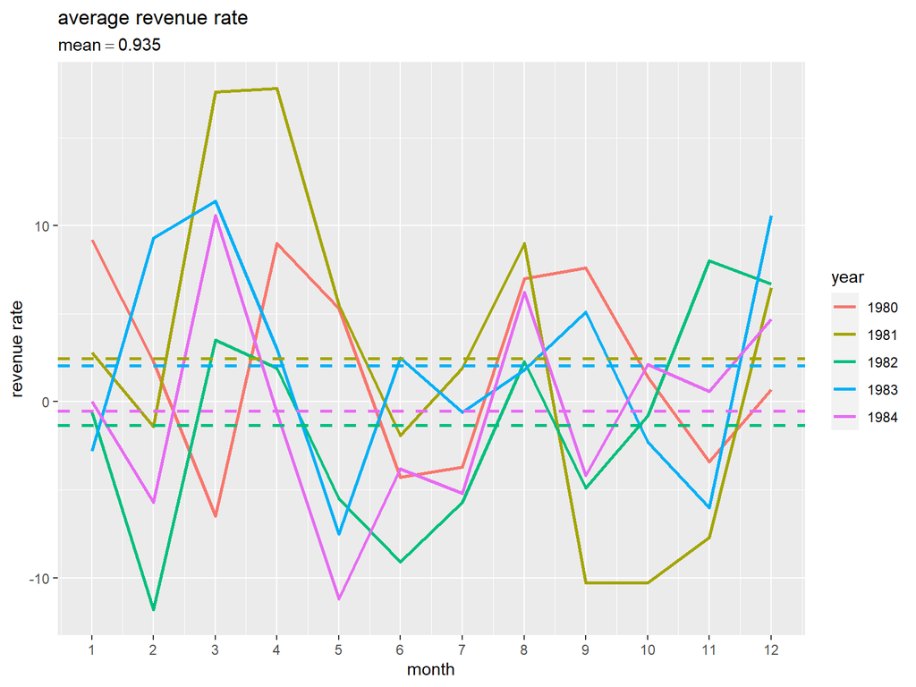

```r
# タイトル用の文字列を作成
stat_label <- paste0(
  "mean==", round(mean(mean_df[["mean"]]), digits = 3)
)

# 月次収益率と平均値を作図
ggplot() +
  geom_line(data = revenue_df,
            mapping = aes(x = month, y = revenue_rate, color = year),
            size = 1) + # 収益率
  geom_hline(data = mean_df, mapping = aes(yintercept = mean, color = year),
             size = 1, linetype ="dashed") + # 平均値
  scale_x_continuous(breaks = 1:12) + # x軸目盛
  labs(title = "average revenue rate",
       subtitle = parse(text = stat_label),
       x = "month", y = "revenue rate")
```

各年の平均収益率を`geom_hline()`で水平線として描画します。  
破線の位置が高いほど、収益率が高いことを表します。ただし、あくまで年間を通した値であり、月ごとの変動を表しません。

そこで、年ごとに標準偏差を計算します。

```r
# 年ごとの標準偏差を計算
sd_df <- revenue_df |>
  dplyr::group_by(year) |> # 年ごとの計算用
  dplyr::mutate(
    mean = mean(revenue_rate),
    sd = sd(revenue_rate) * sqrt(12-1) / sqrt(12)
  )
sd_df
```

```
## # A tibble: 60 × 5
## # Groups:   year [5]
##    month year  revenue_rate   mean    sd
##    <int> <fct>        <dbl>  <dbl> <dbl>
##  1     1 1980           9.2  2.05   5.35
##  2     1 1981           2.8  2.46   9.11
##  3     1 1982          -0.6 -1.33   5.91
##  4     1 1983          -2.8  2.04   5.98
##  5     1 1984           0   -0.542  5.71
##  6     2 1980           2.3  2.05   5.35
##  7     2 1981          -1.4  2.46   9.11
##  8     2 1982         -11.8 -1.33   5.91
##  9     2 1983           9.3  2.04   5.98
## 10     2 1984          -5.7 -0.542  5.71
## # … with 50 more rows
```

`mutate()`を使って標本平均と標本標準偏差を計算します。`mutate()`を使って計算すると、計算に利用した行が集約されません(行数が変化しません)。

年ごとの標準偏差を取り出します。

```r
# 標準偏差を抽出
sd_vec <- sd_df |>
  dplyr::distinct(year, sd) |> # 重複を削除
  dplyr::pull(sd) # 列を抽出
sd_vec
```

```
## [1] 5.352492 9.110750 5.905553 5.979334 5.712188
```

`sd_df`の平均値と標準偏差の値は、12か月分に複製されています。そこで、`distinct()`で重複を除去してから、`pull()`で標準偏差の列を取り出します。

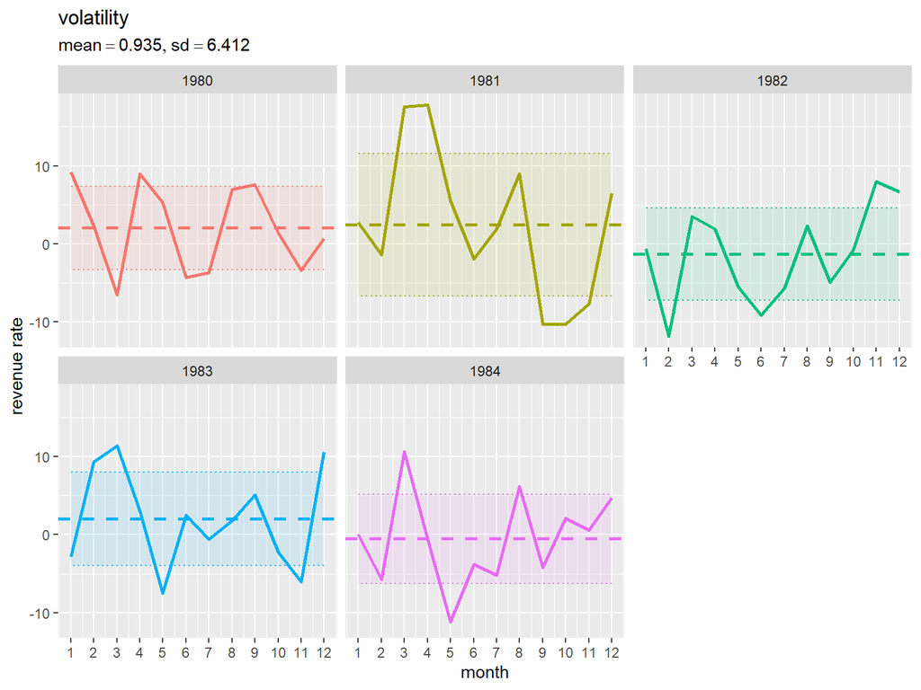

```r
# タイトル用の文字列を作成
stat_label <- paste0(
  "list(",
  "mean==", round(mean(mean_df[["mean"]]), digits = 3),
  ", sd==", round(mean(sd_vec), digits = 3),
  ")"
)

# 月次収益率とボラティリティを作図
ggplot() +
  geom_line(data = revenue_df,
            mapping = aes(x = month, y = revenue_rate, color = year),
            size = 1) + # 収益率
  geom_hline(data = mean_df,
             mapping = aes(yintercept = mean, color = year),
             size = 1, linetype ="dashed") + # 平均値
  geom_ribbon(data = sd_df,
              mapping = aes(x = month, ymin = mean-sd, ymax = mean+sd, color = year, fill = year),
              alpha = 0.1, linetype = "dotted") + # 標準偏差の範囲
  scale_x_continuous(breaks = 1:12) + # x軸目盛
  facet_wrap(year~.) + # グラフを分割
  theme(legend.position = "none") + # 凡例の非表示
  labs(title = "volatility",
       subtitle = parse(text = stat_label),
       x = "month", y = "revenue rate")
```

`geom_ribbon()`で平均値から標準偏差1個分を引いた値と足した値の範囲を描画します。  
各年のグラフが重なると分かりにくくなるので、`facet_wrap()`で年ごとに分割します。

塗りつぶしの範囲が広いほど、変動が大きいことを表します。  
(標準偏差の平均の値が合いませんでした。そもそも標準偏差の平均ってなんですか？)

この講では、標準偏差を利用してボラティリティを比較しました。次講では、シャープレシオを比較します。

# 参考書籍

- 小島寛之『完全独習 統計学入門』ダイヤモンド社,2006年.